# Classification Prediction Problem

Data Science 3 with R (STAT 301-3)

Author

Hannah Li

Published

May 28, 2024

**Github Repo Link**

https://github.com/stat301-3-2024-spring/classification-pred-prob-hannahs-li

## Introduction

For this quarter’s classification prediction problem, the challenge was to predict Chicago Airbnb host status (specifically if they were a superhost or not) as of December 2023 based off of listing, host, and Airbnb characteristics.

This is really important and relevant to everyone, not just those involved in the Kaggle competition, because understanding factors that contribute to whether or not someone is a superhost provides key insights into hospitality and general perception for both hosts and guests. Generally speaking, being a superhost means higher expectations, and achieving this status can lead to more bookings and revenue on Airbnb. From the guest perspective, understanding the factors that influence superhost status will allow them to make informed decisions regarding their stay and Airbnb experience.

## Data Overview

The data used in training these models were supplied by the Kaggle competition.

### Data Quality Check

As noted in the table below, the original dataset was not conducive for predicting. Not only was there missingness in several variables (which were address in the recipe), but also there was also a `bathrooms_text` variable which specified the number of bathrooms and type which produced an error message in all recipes. As a result, I converted it to a numeric value by extracting the numeric input and then dividing it by 2 if the observation had “shared” in its description, as seen in my created variable `true_bathrooms`.

There were also special characters such as (percentages (%)) in `host_response_rate` and `host_acceptance_rate`. This also limited the efficacy and ability of prediction models so I removed these special characters and made these variables numeric.

With the exception of the `id` variable, I converted all character and logical variables into factor variables because factor variables are easier to work with and R-Studio already treats logical variables as factor variables with two levels.

Furthermore, I also extracted the years, instead of specific dates, from all Date variables (`host_since`, `first_review`, `last_review`) because it minimzes noise from daily/monthly fluctuations, especially over a longer period of time as seen in our dataset (2008-2023).

Furthermore, there were a couple of extreme outliers—so much so they surpassed the digit limit of my computer and were all 2147483647 or 547979424—in `minimum_maximum_nights`, `maximum_maximum_nights`, `maximum_nights_avg_ntm`. As a result, I just made them the maximum values in the test dataset given the fact there were only 5 observations.

All the changes to the original dataset are seen in the skim of the cleaned train dataset below. These changes were also made to the test dataset as well.

Skimr Summary of All Variables

| skim_type | skim_variable | n_missing | complete_rate | character.min | character.max | character.empty | character.n_unique | character.whitespace | factor.ordered | factor.n_unique | factor.top_counts | numeric.mean | numeric.sd | numeric.p0 | numeric.p25 | numeric.p50 | numeric.p75 | numeric.p100 |
| --- | --- | --- | --- | --- | --- | --- | --- | --- | --- | --- | --- | --- | --- | --- | --- | --- | --- | --- |
| character | id | 0 | 1.0000000 | 5 | 19 | 0 | 4977 | 0 | NA | NA | NA | NA | NA | NA | NA | NA | NA | NA |
| factor | host_location | 958 | 0.8075146 | NA | NA | NA | NA | NA | FALSE | 146 | Chi: 3226, New: 375, Uni: 49, Sko: 26 | NA | NA | NA | NA | NA | NA | NA |
| factor | host_response_time | 417 | 0.9162146 | NA | NA | NA | NA | NA | FALSE | 4 | wit: 3846, wit: 433, wit: 230, a f: 51 | NA | NA | NA | NA | NA | NA | NA |
| factor | host_is_superhost | 0 | 1.0000000 | NA | NA | NA | NA | NA | FALSE | 2 | FAL: 2793, TRU: 2184 | NA | NA | NA | NA | NA | NA | NA |
| factor | host_neighbourhood | 122 | 0.9754872 | NA | NA | NA | NA | NA | FALSE | 199 | Cam: 363, Riv: 249, Log: 203, Wes: 197 | NA | NA | NA | NA | NA | NA | NA |
| factor | host_verifications | 0 | 1.0000000 | NA | NA | NA | NA | NA | FALSE | 5 | ['e: 3527, ['e: 1089, ['p: 339, ['p: 20 | NA | NA | NA | NA | NA | NA | NA |
| factor | host_has_profile_pic | 0 | 1.0000000 | NA | NA | NA | NA | NA | FALSE | 2 | TRU: 4911, FAL: 66 | NA | NA | NA | NA | NA | NA | NA |
| factor | host_identity_verified | 0 | 1.0000000 | NA | NA | NA | NA | NA | FALSE | 2 | TRU: 4486, FAL: 491 | NA | NA | NA | NA | NA | NA | NA |
| factor | neighbourhood_cleansed | 0 | 1.0000000 | NA | NA | NA | NA | NA | FALSE | 76 | Nea: 638, Wes: 483, Lak: 355, Nea: 334 | NA | NA | NA | NA | NA | NA | NA |
| factor | property_type | 0 | 1.0000000 | NA | NA | NA | NA | NA | FALSE | 44 | Ent: 2516, Ent: 485, Pri: 440, Ent: 391 | NA | NA | NA | NA | NA | NA | NA |
| factor | room_type | 0 | 1.0000000 | NA | NA | NA | NA | NA | FALSE | 4 | Ent: 3801, Pri: 1106, Sha: 44, Hot: 26 | NA | NA | NA | NA | NA | NA | NA |
| factor | has_availability | 0 | 1.0000000 | NA | NA | NA | NA | NA | FALSE | 2 | TRU: 4966, FAL: 11 | NA | NA | NA | NA | NA | NA | NA |
| factor | instant_bookable | 0 | 1.0000000 | NA | NA | NA | NA | NA | FALSE | 2 | FAL: 3441, TRU: 1536 | NA | NA | NA | NA | NA | NA | NA |
| factor | shared_bathrooms | 0 | 1.0000000 | NA | NA | NA | NA | NA | FALSE | 2 | FAL: 4331, TRU: 646 | NA | NA | NA | NA | NA | NA | NA |
| numeric | host_since | 0 | 1.0000000 | NA | NA | NA | NA | NA | NA | NA | NA | 2017.1904762 | 3.2919146 | 2008.00000 | 2015.00000 | 2017.00000 | 2020.00000 | 2023.00000 |
| numeric | host_response_rate | 417 | 0.9162146 | NA | NA | NA | NA | NA | NA | NA | NA | 5.8760965 | 10.1337945 | 1.00000 | 2.00000 | 2.00000 | 2.00000 | 38.00000 |
| numeric | host_acceptance_rate | 290 | 0.9417320 | NA | NA | NA | NA | NA | NA | NA | NA | 41.2978451 | 31.2666318 | 1.00000 | 2.00000 | 60.00000 | 70.00000 | 72.00000 |
| numeric | host_listings_count | 0 | 1.0000000 | NA | NA | NA | NA | NA | NA | NA | NA | 403.8539281 | 1273.0715966 | 1.00000 | 1.00000 | 5.00000 | 23.00000 | 4820.00000 |
| numeric | host_total_listings_count | 0 | 1.0000000 | NA | NA | NA | NA | NA | NA | NA | NA | 568.1444645 | 1766.3911803 | 1.00000 | 2.00000 | 6.00000 | 32.00000 | 8868.00000 |
| numeric | latitude | 0 | 1.0000000 | NA | NA | NA | NA | NA | NA | NA | NA | 41.8916020 | 0.0628161 | 41.64677 | 41.85986 | 41.89581 | 41.93503 | 42.02220 |
| numeric | longitude | 0 | 1.0000000 | NA | NA | NA | NA | NA | NA | NA | NA | -87.6615138 | 0.0443061 | -87.84693 | -87.68476 | -87.65635 | -87.62928 | -87.52954 |
| numeric | accommodates | 0 | 1.0000000 | NA | NA | NA | NA | NA | NA | NA | NA | 4.3930078 | 3.0923382 | 1.00000 | 2.00000 | 4.00000 | 6.00000 | 16.00000 |
| numeric | beds | 48 | 0.9903556 | NA | NA | NA | NA | NA | NA | NA | NA | 2.2949888 | 1.7307080 | 1.00000 | 1.00000 | 2.00000 | 3.00000 | 20.00000 |
| numeric | minimum_nights | 0 | 1.0000000 | NA | NA | NA | NA | NA | NA | NA | NA | 15.6743018 | 43.3767172 | 1.00000 | 2.00000 | 2.00000 | 32.00000 | 1125.00000 |
| numeric | maximum_nights | 0 | 1.0000000 | NA | NA | NA | NA | NA | NA | NA | NA | 560.1332128 | 444.3081693 | 1.00000 | 180.00000 | 365.00000 | 1125.00000 | 1125.00000 |
| numeric | minimum_minimum_nights | 0 | 1.0000000 | NA | NA | NA | NA | NA | NA | NA | NA | 16.0148684 | 44.8503740 | 1.00000 | 2.00000 | 2.00000 | 32.00000 | 1125.00000 |
| numeric | maximum_minimum_nights | 0 | 1.0000000 | NA | NA | NA | NA | NA | NA | NA | NA | 43.0088407 | 108.7886307 | 1.00000 | 2.00000 | 3.00000 | 32.00000 | 1125.00000 |
| numeric | minimum_maximum_nights | 0 | 1.0000000 | NA | NA | NA | NA | NA | NA | NA | NA | 776.3871810 | 448.4549429 | 1.00000 | 365.00000 | 1125.00000 | 1125.00000 | 1125.00000 |
| numeric | maximum_maximum_nights | 0 | 1.0000000 | NA | NA | NA | NA | NA | NA | NA | NA | 776.3871810 | 448.4549429 | 1.00000 | 365.00000 | 1125.00000 | 1125.00000 | 1125.00000 |
| numeric | minimum_nights_avg_ntm | 0 | 1.0000000 | NA | NA | NA | NA | NA | NA | NA | NA | 39.7422544 | 98.0134083 | 1.00000 | 2.00000 | 3.00000 | 32.00000 | 1125.00000 |
| numeric | maximum_nights_avg_ntm | 0 | 1.0000000 | NA | NA | NA | NA | NA | NA | NA | NA | 776.3871810 | 448.4549429 | 1.00000 | 365.00000 | 1125.00000 | 1125.00000 | 1125.00000 |
| numeric | availability_30 | 0 | 1.0000000 | NA | NA | NA | NA | NA | NA | NA | NA | 15.9789030 | 12.1515317 | 0.00000 | 0.00000 | 18.00000 | 29.00000 | 30.00000 |
| numeric | availability_60 | 0 | 1.0000000 | NA | NA | NA | NA | NA | NA | NA | NA | 35.8872815 | 24.0479147 | 0.00000 | 6.00000 | 46.00000 | 59.00000 | 60.00000 |
| numeric | availability_90 | 0 | 1.0000000 | NA | NA | NA | NA | NA | NA | NA | NA | 56.6264818 | 35.6300171 | 0.00000 | 16.00000 | 75.00000 | 88.00000 | 90.00000 |
| numeric | availability_365 | 0 | 1.0000000 | NA | NA | NA | NA | NA | NA | NA | NA | 200.3851718 | 135.9149836 | 0.00000 | 76.00000 | 207.00000 | 344.00000 | 365.00000 |
| numeric | number_of_reviews | 0 | 1.0000000 | NA | NA | NA | NA | NA | NA | NA | NA | 48.0638939 | 96.2463697 | 0.00000 | 1.00000 | 14.00000 | 57.00000 | 3501.00000 |
| numeric | number_of_reviews_ltm | 0 | 1.0000000 | NA | NA | NA | NA | NA | NA | NA | NA | 13.8328310 | 20.6420404 | 0.00000 | 0.00000 | 5.00000 | 22.00000 | 596.00000 |
| numeric | number_of_reviews_l30d | 0 | 1.0000000 | NA | NA | NA | NA | NA | NA | NA | NA | 0.8189672 | 1.8039953 | 0.00000 | 0.00000 | 0.00000 | 1.00000 | 39.00000 |
| numeric | first_review | 1040 | 0.7910388 | NA | NA | NA | NA | NA | NA | NA | NA | 2020.6949454 | 2.5261151 | 2010.00000 | 2019.00000 | 2022.00000 | 2023.00000 | 2023.00000 |
| numeric | last_review | 1040 | 0.7910388 | NA | NA | NA | NA | NA | NA | NA | NA | 2022.7708915 | 0.8176384 | 2015.00000 | 2023.00000 | 2023.00000 | 2023.00000 | 2023.00000 |
| numeric | review_scores_rating | 1039 | 0.7912397 | NA | NA | NA | NA | NA | NA | NA | NA | 4.7604266 | 0.4047850 | 1.00000 | 4.71000 | 4.86000 | 4.98000 | 5.00000 |
| numeric | review_scores_accuracy | 1039 | 0.7912397 | NA | NA | NA | NA | NA | NA | NA | NA | 4.7940960 | 0.3854258 | 1.00000 | 4.76000 | 4.90000 | 4.99000 | 5.00000 |
| numeric | review_scores_cleanliness | 1040 | 0.7910388 | NA | NA | NA | NA | NA | NA | NA | NA | 4.7481941 | 0.4138367 | 1.00000 | 4.69000 | 4.87000 | 4.99000 | 5.00000 |
| numeric | review_scores_checkin | 1039 | 0.7912397 | NA | NA | NA | NA | NA | NA | NA | NA | 4.8409446 | 0.3447330 | 1.00000 | 4.82000 | 4.93000 | 5.00000 | 5.00000 |
| numeric | review_scores_communication | 1040 | 0.7910388 | NA | NA | NA | NA | NA | NA | NA | NA | 4.8536754 | 0.3671097 | 1.00000 | 4.86000 | 4.95000 | 5.00000 | 5.00000 |
| numeric | review_scores_location | 1039 | 0.7912397 | NA | NA | NA | NA | NA | NA | NA | NA | 4.7456628 | 0.4029945 | 1.00000 | 4.69000 | 4.87000 | 4.98000 | 5.00000 |
| numeric | review_scores_value | 1039 | 0.7912397 | NA | NA | NA | NA | NA | NA | NA | NA | 4.6689055 | 0.4407080 | 1.00000 | 4.61000 | 4.77000 | 4.89000 | 5.00000 |
| numeric | calculated_host_listings_count | 0 | 1.0000000 | NA | NA | NA | NA | NA | NA | NA | NA | 57.3815552 | 165.0723134 | 1.00000 | 1.00000 | 4.00000 | 20.00000 | 643.00000 |
| numeric | calculated_host_listings_count_entire_homes | 0 | 1.0000000 | NA | NA | NA | NA | NA | NA | NA | NA | 54.3811533 | 165.7852381 | 0.00000 | 1.00000 | 2.00000 | 10.00000 | 643.00000 |
| numeric | calculated_host_listings_count_private_rooms | 0 | 1.0000000 | NA | NA | NA | NA | NA | NA | NA | NA | 2.8334338 | 8.8983510 | 0.00000 | 0.00000 | 0.00000 | 1.00000 | 61.00000 |
| numeric | calculated_host_listings_count_shared_rooms | 0 | 1.0000000 | NA | NA | NA | NA | NA | NA | NA | NA | 0.1042797 | 1.2254731 | 0.00000 | 0.00000 | 0.00000 | 0.00000 | 20.00000 |
| numeric | reviews_per_month | 1040 | 0.7910388 | NA | NA | NA | NA | NA | NA | NA | NA | 1.9262535 | 1.9875798 | 0.01000 | 0.57000 | 1.58000 | 2.80000 | 56.20000 |
| numeric | true_bathrooms | 4 | 0.9991963 | NA | NA | NA | NA | NA | NA | NA | NA | 1.4209733 | 0.8069760 | 0.00000 | 1.00000 | 1.00000 | 2.00000 | 11.50000 |

### Inspecting the Target Variable (`host_is_superhost`)

[figure not shown]

There was no missingness in the target variable `host_is_superhost`, and while it is not completely balanced as it there are more normal hosts than there are superhosts (2793: 2184), the difference is very minimal, not requiring up- or down-sampling.

## Final Models Selection

### Selection Process

My first selected model was chosen based off the highest ROC_AUC. Not only was this metric used in evaluating model performance in the Kaggle competition, but also because it indicates the model’s ability to distinguish between the two classes (superhost or not) across different threshold values. As a result, a higher ROC_AUC is more desirable because it indicates that the model is more likely to correctly classify outcomes.

Best Performing Models Based on Metrics Table shows each model’s ROC_AUC from best to worst. When predicting new data with the testing data set, the worst model is the Logistic Regression with the kitchen sink recipe with a ROC_AUC of 0.86098, while my best model, a Light GBM Boosted Tree with a feature engineered recipe, had an ROC_AUC of 0.96238.

| models | recipes | roc_auc | runtimes |
| --- | --- | --- | --- |
| Boosted Tree (Light GBM) | Feature Engineering | 0.96238 | 2013.138 |
| Boosted Tree (Light GBM) | Kitchen Sink | 0.95985 | 1486.823 |
| Boosted Tree (XGBoost) | Feature Engineering | 0.95834 | 843.896 |
| Boosted Tree (XGBoost) | Kitchen Sink | 0.95784 | 1044.745 |
| SVM Rbf | Feature Engineering | 0.91386 | 969.727 |
| SVM Rbf | Kitchen Sink | 0.91360 | 1555.000 |
| SVM Poly | Feature Engineering | 0.90708 | 890.435 |
| SVM Poly | Kitchen Sink | 0.90399 | 2139.584 |
| Logistic Regression | Feature Engineering | 0.87164 | 20.653 |
| Logistic Regression | Kitchen Sink | 0.86098 | 15.877 |

## Methods

### Overview

I use stratified resampling to fold my `train` dataset, using the target variable as the strata. This also helped me tune my models to select optimal hyperparameters and recipe modifications.

### `train` Data Splitting and Folding

I folded the `train` data set using a v-fold cross validation with 5 folds and 3 repeats to fit/tune/train each model 15 times, using the target variable (`host_is_superhost`) to ensure the distribution of the variable is similar in all of the datasets.

### Recipe

Both models used the same feature engineering recipe, which primarily handled novel levels, missingness, and created interaction terms between similiar variables (some of which had joint missingness). It also removed irrelevant variables (`id`, variables with near-zero variance, and normalized numeric variables to follow a normal distribution). The annotations in the recipe below shows a general overview of each step while the section below provides a more detailed overview and reasoning of each step.

```r
recipe_fe <- recipe(host_is_superhost ~., data = train) |>
  step_rm(id) |>
  # adjust for novel levels found in the following variables:
  step_novel(neighbourhood_cleansed) |>
  step_novel(host_neighbourhood) |>
  step_novel(host_location) |>
  # created interaction terms between the first and last review
  step_interact(~first_review:last_review) |>
  # created interaction terms between the all the review scores
  step_interact(~review_scores_rating:
                  reviews_per_month:
                  review_scores_accuracy:
                  review_scores_cleanliness:
                  review_scores_checkin:
                  review_scores_communication:
                  review_scores_location:
                  review_scores_value
                ) |>
  # deal with missingnessness
  step_impute_median(all_numeric_predictors()) |>
  step_impute_mode(all_nominal_predictors()) |>
  # prevent overfitting of the training data
  step_other(threshold = 0.05) |>
  # dummied categorical variables
  step_dummy(all_nominal_predictors()) |>
  # removed predictors with near-zero variance/little to none variation
  step_nzv(all_numeric_predictors()) |>
  # standarize and ensure all numeric predictors follow a normal distribution
  step_normalize(all_numeric_predictors())
```

`step_rm`: removed `id` variable because it was irrelevent towards actually predicting the target variable.

`step_novel`: adjusted for the novel levels found in `neighbourhood_cleansed`, `host_neighbourhood`, and `host_location`.

`step_interact` of `first_review` and `last_review` variables: I also created interaction terms between `first_review` and `last_review` because the timing of the first and last review could indicate how the perceived and actual property value shifted over time, which is crucial to both understanding and predicting our target variable.

`step_interact` of review scores variables: I created interaction terms between the all the review scores because they all had joint missingness. Also, guests might rate different aspects of their experience—accuracy, cleanliness, communication, check-in, location, value, location—alongside other factors like timing (`review_scores_month`) that influences their overall perception of their Airbnb experience. As a result, we need to examine how these variables individually and collectively influence perception of an Airbnb’s value and their subsequent prices.

`step_other`: To prevent overfitting of the data, I put the nominal predictors that occured less than 5% of the time into a new level (“Other”).

`step_dummy`, `step_nzv`, & `step_normalize`: Finally, I prepped the data for my model: dummying my categorical variables, removing predictors with near-zero variance/little to none variation because they would be unhelpful for modeling, and normalizing my numeric variables to follow a normal distribution.

### Model Details & Their Optimal Parameters

#### Boosted Tree (LGBM)

Light GBM boosted trees create an prediction ensemble using decision trees, where each tree is influenced by the results of previous trees.

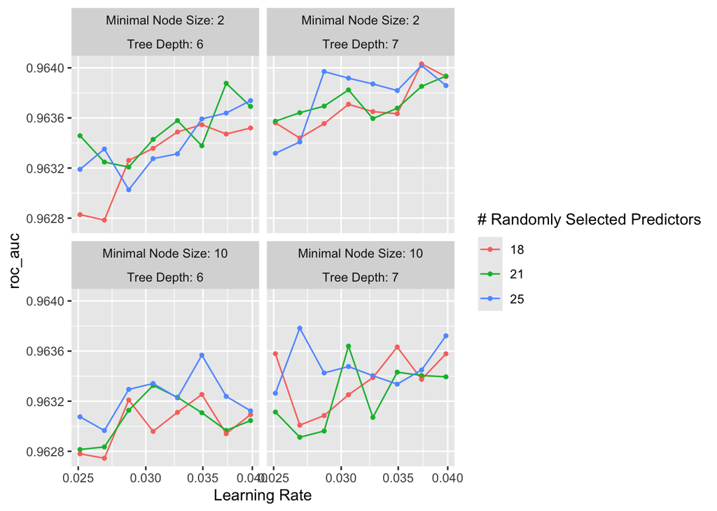

The table below shows the parameters of my best performing Light GBM model, in which mtry is 18, min_n is 2, tree_depth is 7, and the learning rate is 0.0372759.

| mtry | min_n | tree_depth | learn_rate | .config |
| --- | --- | --- | --- | --- |
| 18 | 2 | 7 | 0.0372759 | Preprocessor1_Model79 |

#### SVM Poly

Support Vector Machines with polynomial kernels (SVM Poly models) predict data by maximizing the width of class margin using a polynomial class boundary.

The table below shows the parameters of my best performing SVM Poly model, in which cost is 2.763, degree is 2, and scale_factor is 0.016.

| cost | degree | scale_factor | .config |
| --- | --- | --- | --- |
| 2.763452 | 2 | 0.0160358 | Preprocessor1_Model19 |

## Conclusion

In conclusion, this analysis aimed to predict Chicago Airbnb host status, specifically identifying superhosts, based on various listing, host, and Airbnb characteristics. Through meticulous data preprocessing, model training, and evaluation, several key findings emerged.

The selected models, Light GBM boosted trees and SVM with polynomial kernels (SVM Poly), were assessed based on their ROC_AUC scores, indicating their ability to distinguish between superhosts and non-superhosts. The Light GBM model outperformed the SVM Poly model in terms of ROC_AUC, showcasing its superior predictive capability. However, the SVM Poly model, despite its slightly lower performance, offers robustness and generalizability, making it a valuable alternative for analyzing other similar datasets/

Insights gained from this analysis have significant implications for both hosts and guests on Airbnb. Hosts can leverage the identified factors contributing to superhost status to enhance their listings and services, ultimately improving their chances of achieving superhost status and attracting more bookings. Similarly, guests can utilize this information to make more informed decisions when selecting accommodations, ensuring a better Airbnb experience.

Future research could definitely explore other cities and even other booking apps and hotels to futher understand booking platforms and hospitality ratings and expectations.